# 5.2 Essential Functionality

### 1. Reindexing

An important method on pandas objects is `reindex`, which means to create a new object with the data *conformed* to a new index. Consider an example:

```python
import pandas as pd
import numpy as np
```

```python
obj = pd.Series([4.5, 7.2, -5.3, 3.6], index=['d', 'b', 'a', 'c'])
obj
```

```
d    4.5
b    7.2
a   -5.3
c    3.6
dtype: float64
```

Calling `reindex` on this Series rearranges the data according to the new index, introducing missing values if any index values were not already present:

```python
obj2 = obj.reindex(['a', 'b', 'c', 'd', 'e'])
obj2
```

```
a   -5.3
b    7.2
c    3.6
d    4.5
e    NaN
dtype: float64
```

For ordered data like **time series**, it may be desirable to do some interpolation or filling of values when reindexing.  
The `method` option allows us to do this, using a method such as `ffill`, which forward-fills the values:

```python
obj3 = pd.Series(['blue', 'purple', 'yellow'], index=[0, 2, 4])
obj3
```

```
0      blue
2    purple
4    yellow
dtype: object
```

```python
obj3.reindex(range(6), method='ffill')
```

```
0      blue
1      blue
2    purple
3    purple
4    yellow
5    yellow
dtype: object
```

**With DataFrame, reindex can alter either the (row) index, columns, or both.** When passed only a sequence, it reindexes the rows in the result:

```python
frame = pd.DataFrame(np.arange(9).reshape((3, 3)),\
                     index=['a', 'c', 'd'], columns=['Ohio', 'Texas', 'California'])
frame
```

|  | Ohio | Texas | California |
| --- | --- | --- | --- |
| a | 0 | 1 | 2 |
| c | 3 | 4 | 5 |
| d | 6 | 7 | 8 |

```python
frame2 = frame.reindex(['a', 'b', 'c', 'd'])
frame2
```

|  | Ohio | Texas | California |
| --- | --- | --- | --- |
| a | 0.0 | 1.0 | 2.0 |
| b | NaN | NaN | NaN |
| c | 3.0 | 4.0 | 5.0 |
| d | 6.0 | 7.0 | 8.0 |

```python
states = ['Texas', 'Utah', 'California']
frame.reindex(columns=states)
```

|  | Texas | Utah | California |
| --- | --- | --- | --- |
| a | 1 | NaN | 2 |
| c | 4 | NaN | 5 |
| d | 7 | NaN | 8 |

As we’ll explore in more detail, you can reindex more succinctly by **label-indexing with `loc`**, and many users prefer to use it exclusively:

```python
frame.loc[['a', 'c', 'd'], ['Ohio', 'Texas']]
```

|  | Ohio | Texas |
| --- | --- | --- |
| a | 0 | 1 |
| c | 3 | 4 |
| d | 6 | 7 |

#### See Table 5-3 for more about the arguments to`reindex`.

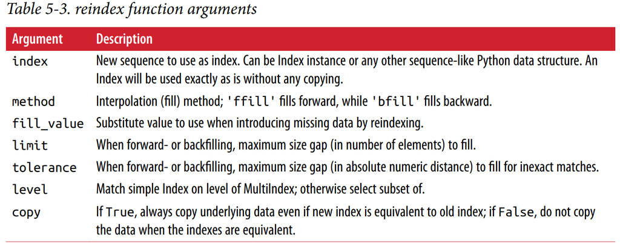

### 2. Dropping Entries from an Axis

- Dropping one or more entries from an axis is easy **if you already have an index array or list without those entries.**
- The `drop` method will **return a new object** with the indicated value or values deleted from an axis:

```python
obj = pd.Series(np.arange(5.), index=['a', 'b', 'c', 'd', 'e'])
obj
```

```
a    0.0
b    1.0
c    2.0
d    3.0
e    4.0
dtype: float64
```

```python
new_obj = obj.drop('c')
new_obj
```

```
a    0.0
b    1.0
d    3.0
e    4.0
dtype: float64
```

```python
obj.drop(['d', 'c'])
```

```
a    0.0
b    1.0
e    4.0
dtype: float64
```

#### With DataFrame, index values can be deleted from either axis.

```python
data = pd.DataFrame(np.arange(16).reshape((4, 4)),\
                    index=['Ohio', 'Colorado', 'Utah', 'New York'],\
                    columns=['one', 'two', 'three', 'four'])
data
```

|  | one | two | three | four |
| --- | --- | --- | --- | --- |
| Ohio | 0 | 1 | 2 | 3 |
| Colorado | 4 | 5 | 6 | 7 |
| Utah | 8 | 9 | 10 | 11 |
| New York | 12 | 13 | 14 | 15 |

#### Calling `drop` with a sequence of labels will drop values from the row labels (axis 0)

```python
data.drop(['Colorado', 'Ohio'])
```

|  | one | two | three | four |
| --- | --- | --- | --- | --- |
| Utah | 8 | 9 | 10 | 11 |
| New York | 12 | 13 | 14 | 15 |

You can drop values from the columns by passing `axis=1` or `axis='columns'`

```python
data.drop(['two', 'four'], axis='columns')
```

|  | one | three |
| --- | --- | --- |
| Ohio | 0 | 2 |
| Colorado | 4 | 6 |
| Utah | 8 | 10 |
| New York | 12 | 14 |

Many functions, like `drop`, which modify the `size` or `shape` of a Series or DataFrame, can **manipulate an object in-place without returning a new object:**

```python
obj
```

```
a    0.0
b    1.0
c    2.0
d    3.0
e    4.0
dtype: float64
```

```python
obj.drop('c', inplace=True)
obj
```

```
a    0.0
b    1.0
d    3.0
e    4.0
dtype: float64
```

#### Be careful with the `inplace`, as it destroys any data that is dropped

### 3. Indexing, Selection, and Filtering

Series indexing `(obj[...])` works analogously to NumPy array indexing, except you can use the Series’s index values instead of only integers.

```python
obj = pd.Series(np.arange(4.), index=['a', 'b', 'c', 'd'])
obj
```

```
a    0.0
b    1.0
c    2.0
d    3.0
dtype: float64
```

```python
obj['b']
```

```
1.0
```

```python
obj[1]
```

```
1.0
```

```python
obj[2:4]
```

```
c    2.0
d    3.0
dtype: float64
```

```python
obj[['b', 'a', 'd']]
```

```
b    1.0
a    0.0
d    3.0
dtype: float64
```

```python
obj[obj < 2]
```

```
a    0.0
b    1.0
dtype: float64
```

Slicing with labels behaves differently than normal Python **slicing in that the end‐point is inclusive:**

```python
obj['b':'d']
```

```
b    1.0
c    2.0
d    3.0
dtype: float64
```

`Setting` using these methods modifies the corresponding section of the Series:

```python
obj['b':'c'] = 5
obj
```

```
a    0.0
b    5.0
c    5.0
d    3.0
dtype: float64
```

#### Indexing into a DataFrame is for retrieving one or more columns either with a single value or seq

```python
data
```

|  | one | two | three | four |
| --- | --- | --- | --- | --- |
| Ohio | 0 | 1 | 2 | 3 |
| Colorado | 4 | 5 | 6 | 7 |
| Utah | 8 | 9 | 10 | 11 |
| New York | 12 | 13 | 14 | 15 |

```python
data[['three', 'one']]
```

|  | three | one |
| --- | --- | --- |
| Ohio | 2 | 0 |
| Colorado | 6 | 4 |
| Utah | 10 | 8 |
| New York | 14 | 12 |

Indexing like this has a few special cases. First, slicing or selecting data with a boolean array:

```python
data[data['three'] > 5]
```

|  | one | two | three | four |
| --- | --- | --- | --- | --- |
| Colorado | 4 | 5 | 6 | 7 |
| Utah | 8 | 9 | 10 | 11 |
| New York | 12 | 13 | 14 | 15 |

Another use case is in indexing with a boolean DataFrame, such as one produced by a scalar comparison

```python
data < 5
```

|  | one | two | three | four |
| --- | --- | --- | --- | --- |
| Ohio | True | True | True | True |
| Colorado | True | False | False | False |
| Utah | False | False | False | False |
| New York | False | False | False | False |

```python
data[data < 5] = 0
data
```

|  | one | two | three | four |
| --- | --- | --- | --- | --- |
| Ohio | 0 | 0 | 0 | 0 |
| Colorado | 0 | 5 | 6 | 7 |
| Utah | 8 | 9 | 10 | 11 |
| New York | 12 | 13 | 14 | 15 |

#### This makes DataFrame syntactically more like a two-dimensional NumPy array in this particular case.

### 4. Selection with loc and iloc

The methods `loc` and `iloc` enable you to select a subset of the rows and columns from a DataFrame with NumPy-like notation using either axis `labels (loc)` or `integers (iloc)`.

```python
 data.loc['Colorado', ['two', 'three']]
```

```
two      5
three    6
Name: Colorado, dtype: int32
```

We’ll then perform some similar selections with integers using iloc:

```python
data.iloc[2, [3, 0, 1]]
```

```
four    11
one      8
two      9
Name: Utah, dtype: int32
```

```python
data.iloc[[1, 2], [3, 0, 1]]
```

|  | four | one | two |
| --- | --- | --- | --- |
| Colorado | 7 | 0 | 5 |
| Utah | 11 | 8 | 9 |

Both indexing functions work with slices in addition to single labels or lists of labels:

```python
data.loc[:'Utah', 'two']
```

```
Ohio        0
Colorado    5
Utah        9
Name: two, dtype: int32
```

```python
data.iloc[:, :3][data.three > 5]
```

|  | one | two | three |
| --- | --- | --- | --- |
| Colorado | 0 | 5 | 6 |
| Utah | 8 | 9 | 10 |
| New York | 12 | 13 | 14 |

So there are many ways to select and **rearrange the data contained in a pandas object.** For DataFrame, Table 5-4 provides a short summary of many of them.

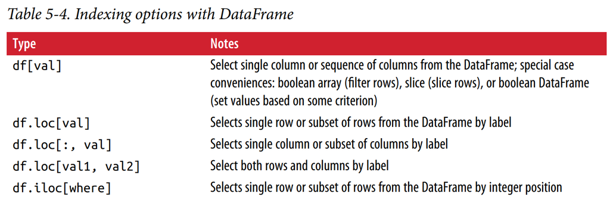

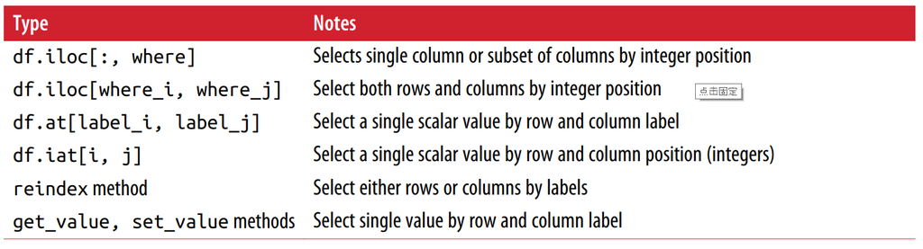

### 5. Integer Indexes

Working with pandas objects indexed by integers is something that often trips up new users due to some differences with indexing semantics on built-in Python data structures like lists and tuples.

```python
ser = pd.Series(np.arange(3.))
ser
```

```
0    0.0
1    1.0
2    2.0
dtype: float64
```

In this case, pandas could “fall back” on integer indexing, but it’s difficult to do this in general without introducing subtle bugs. Here we have an index containing 0, 1, 2, **but inferring what the user wants (label-based indexing or position-based) is difficult:**

```python
ser[-1]
```

[output not shown]

on the other hand, with a non-integer index, there is no potential for ambiguity:

```python
ser2 = pd.Series(np.arange(3.), index=['a', 'b', 'c'])
ser2[-1]
```

```
2.0
```

#### For more precise handling, use`loc` (for labels) or`iloc`(for integers):

```python
ser.loc[:1]
```

```
0    0.0
1    1.0
dtype: float64
```

```python
ser.iloc[:1]
```

```
0    0.0
dtype: float64
```

### 6. Arithmetic and Data Alignment

- When you are adding together objects, if any index pairs are not the same, the respective index in the result will be the union of the index pairs
- For users with database experience, this is similar to an automatic `outer join` on the index labels. Let’s look at an example:

```python
s1 = pd.Series([7.3, -2.5, 3.4, 1.5], index=['a', 'c', 'd', 'e'])
s2 = pd.Series([-2.1, 3.6, -1.5, 4, 3.1],index=['a', 'c', 'e', 'f', 'g'])
s1 + s2
```

```
a    5.2
c    1.1
d    NaN
e    0.0
f    NaN
g    NaN
dtype: float64
```

- The internal data alignment introduces missing values in the label locations that don’t overlap.
- Missing values will then propagate in further arithmetic computations.

#### In the case of DataFrame, alignment is performed on both the rows and the columns:

```python
df1 = pd.DataFrame(np.arange(9.).reshape((3, 3)), columns=list('bcd'),index=['Ohio', 'Texas', 'Colorado'])
df2 = pd.DataFrame(np.arange(12.).reshape((4, 3)), columns=list('bde'),index=['Utah', 'Ohio', 'Texas', 'Oregon'])
df1
```

|  | b | c | d |
| --- | --- | --- | --- |
| Ohio | 0.0 | 1.0 | 2.0 |
| Texas | 3.0 | 4.0 | 5.0 |
| Colorado | 6.0 | 7.0 | 8.0 |

```python
df2
```

|  | b | d | e |
| --- | --- | --- | --- |
| Utah | 0.0 | 1.0 | 2.0 |
| Ohio | 3.0 | 4.0 | 5.0 |
| Texas | 6.0 | 7.0 | 8.0 |
| Oregon | 9.0 | 10.0 | 11.0 |

Adding these together returns a DataFrame whose index and columns are the unions of the ones in each DataFrame:

```python
df1 + df2
```

|  | b | c | d | e |
| --- | --- | --- | --- | --- |
| Colorado | NaN | NaN | NaN | NaN |
| Ohio | 3.0 | NaN | 6.0 | NaN |
| Oregon | NaN | NaN | NaN | NaN |
| Texas | 9.0 | NaN | 12.0 | NaN |
| Utah | NaN | NaN | NaN | NaN |

- Since the 'c' and 'e' columns are not found in both DataFrame objects, they appear as all missing in the result.
- The same holds for the rows whose labels are not common to both objects

### 7. Arithmetic methods with fill values

In arithmetic operations between differently indexed objects, you might want to fill with a special value, like 0, when an axis label is found in one object but not the other:

```python
df1 = pd.DataFrame(np.arange(12.).reshape((3, 4)),columns=list('abcd'))
df2 = pd.DataFrame(np.arange(20.).reshape((4, 5)),columns=list('abcde'))
df1
```

|  | a | b | c | d |
| --- | --- | --- | --- | --- |
| 0 | 0.0 | 1.0 | 2.0 | 3.0 |
| 1 | 4.0 | 5.0 | 6.0 | 7.0 |
| 2 | 8.0 | 9.0 | 10.0 | 11.0 |

```python
df2
```

|  | a | b | c | d | e |
| --- | --- | --- | --- | --- | --- |
| 0 | 0.0 | 1.0 | 2.0 | 3.0 | 4.0 |
| 1 | 5.0 | 6.0 | 7.0 | 8.0 | 9.0 |
| 2 | 10.0 | 11.0 | 12.0 | 13.0 | 14.0 |
| 3 | 15.0 | 16.0 | 17.0 | 18.0 | 19.0 |

```python
df2.loc[1, 'b'] = np.nan
df2
```

|  | a | b | c | d | e |
| --- | --- | --- | --- | --- | --- |
| 0 | 0.0 | 1.0 | 2.0 | 3.0 | 4.0 |
| 1 | 5.0 | NaN | 7.0 | 8.0 | 9.0 |
| 2 | 10.0 | 11.0 | 12.0 | 13.0 | 14.0 |
| 3 | 15.0 | 16.0 | 17.0 | 18.0 | 19.0 |

Adding these together results in `NA` values in the locations that don’t overlap:

```python
df1 + df2
```

|  | a | b | c | d | e |
| --- | --- | --- | --- | --- | --- |
| 0 | 0.0 | 2.0 | 4.0 | 6.0 | NaN |
| 1 | 9.0 | NaN | 13.0 | 15.0 | NaN |
| 2 | 18.0 | 20.0 | 22.0 | 24.0 | NaN |
| 3 | NaN | NaN | NaN | NaN | NaN |

#### Using the `add` method on df1, I pass df2 and an argument to`fill_value`:

```python
df1.add(df2, fill_value=0)
```

|  | a | b | c | d | e |
| --- | --- | --- | --- | --- | --- |
| 0 | 0.0 | 2.0 | 4.0 | 6.0 | 4.0 |
| 1 | 9.0 | 5.0 | 13.0 | 15.0 | 9.0 |
| 2 | 18.0 | 20.0 | 22.0 | 24.0 | 14.0 |
| 3 | 15.0 | 16.0 | 17.0 | 18.0 | 19.0 |

#### when reindexing a Series or DataFrame, you can also specify a different fill value:

```python
df1.reindex(columns=df2.columns, fill_value=0)
```

|  | a | b | c | d | e |
| --- | --- | --- | --- | --- | --- |
| 0 | 0.0 | 1.0 | 2.0 | 3.0 | 0 |
| 1 | 4.0 | 5.0 | 6.0 | 7.0 | 0 |
| 2 | 8.0 | 9.0 | 10.0 | 11.0 | 0 |

See Table 5-5 for a listing of Series and DataFrame methods for arithmetic.**Each of them has a counterpart, starting with the letter `r`,** that has arguments flipped.

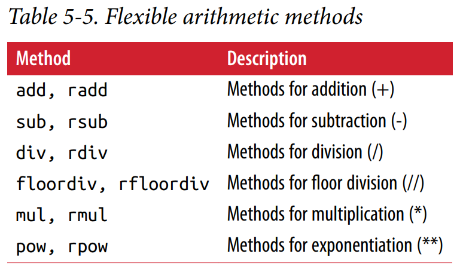

```python
df1.rdiv(1) # equal to `1 / df1`
```

|  | a | b | c | d |
| --- | --- | --- | --- | --- |
| 0 | inf | 1.000000 | 0.500000 | 0.333333 |
| 1 | 0.250 | 0.200000 | 0.166667 | 0.142857 |
| 2 | 0.125 | 0.111111 | 0.100000 | 0.090909 |

### 8. Operations between DataFrame and Series

As with NumPy arrays of different dimensions, arithmetic between DataFrame and Series is also defined.

```python
arr = np.arange(12.).reshape((3, 4))
arr
```

```
array([[ 0.,  1.,  2.,  3.],
       [ 4.,  5.,  6.,  7.],
       [ 8.,  9., 10., 11.]])
```

```python
arr[0]
```

```
array([0., 1., 2., 3.])
```

```python
arr - arr[0]
```

```
array([[0., 0., 0., 0.],
       [4., 4., 4., 4.],
       [8., 8., 8., 8.]])
```

When we **subtract `arr[0]` from `arr`**, the subtraction is performed once for each row. This is referred to as *broadcasting*.

```python
frame = pd.DataFrame(np.arange(12.).reshape((4, 3)),columns=list('bde'),index=['Utah', 'Ohio', 'Texas', 'Oregon'])
frame
```

|  | b | d | e |
| --- | --- | --- | --- |
| Utah | 0.0 | 1.0 | 2.0 |
| Ohio | 3.0 | 4.0 | 5.0 |
| Texas | 6.0 | 7.0 | 8.0 |
| Oregon | 9.0 | 10.0 | 11.0 |

```python
series = frame.iloc[0]
series
```

```
b    0.0
d    1.0
e    2.0
Name: Utah, dtype: float64
```

```python
frame - series
```

|  | b | d | e |
| --- | --- | --- | --- |
| Utah | 0.0 | 0.0 | 0.0 |
| Ohio | 3.0 | 3.0 | 3.0 |
| Texas | 6.0 | 6.0 | 6.0 |
| Oregon | 9.0 | 9.0 | 9.0 |

If an index value is **not found in either the DataFrame’s columns or the Series’s index**, **the objects will be reindexed to form the union:**

```python
series2 = pd.Series(range(3), index=['b', 'e', 'f'])
frame.add(series2,fill_value= None)
```

|  | b | d | e | f |
| --- | --- | --- | --- | --- |
| Utah | 0.0 | NaN | 3.0 | NaN |
| Ohio | 3.0 | NaN | 6.0 | NaN |
| Texas | 6.0 | NaN | 9.0 | NaN |
| Oregon | 9.0 | NaN | 12.0 | NaN |

```python
series3 = frame['d']
series3
```

```
Utah       1.0
Ohio       4.0
Texas      7.0
Oregon    10.0
Name: d, dtype: float64
```

#### If you want to instead broadcast over the columns, matching on the rows, you have to use one of the arithmetic methods.

```python
frame.sub(series3, axis='index')
```

|  | b | d | e |
| --- | --- | --- | --- |
| Utah | -1.0 | 0.0 | 1.0 |
| Ohio | -1.0 | 0.0 | 1.0 |
| Texas | -1.0 | 0.0 | 1.0 |
| Oregon | -1.0 | 0.0 | 1.0 |

### 9. Function Application and Mapping

NumPy ufuncs (element-wise array methods) also work with pandas objects:

```python
frame = pd.DataFrame(np.random.randn(4, 3), columns=list('bde'),\
                     index=['Utah', 'Ohio', 'Texas', 'Oregon'])
frame
```

|  | b | d | e |
| --- | --- | --- | --- |
| Utah | -0.375160 | 0.167820 | -0.142158 |
| Ohio | 0.263375 | 0.249337 | 0.433159 |
| Texas | -1.711615 | 0.453431 | 0.617106 |
| Oregon | 1.259501 | 2.524011 | 1.812199 |

```python
np.abs(frame)
```

|  | b | d | e |
| --- | --- | --- | --- |
| Utah | 0.375160 | 0.167820 | 0.142158 |
| Ohio | 0.263375 | 0.249337 | 0.433159 |
| Texas | 1.711615 | 0.453431 | 0.617106 |
| Oregon | 1.259501 | 2.524011 | 1.812199 |

Another frequent operation is applying a function on one-dimensional arrays to each column or row. **DataFrame’s `apply` method does exactly this:**

```python
f = lambda x: x.max() - x.min()
frame.apply(f)
```

```
b    2.971116
d    2.356191
e    1.954356
dtype: float64
```

```python
frame.apply(f,axis=1)
```

```
Utah      0.542980
Ohio      0.183822
Texas     2.328721
Oregon    1.264509
dtype: float64
```

- Many of the most **common array statistics (like `sum` and `mean`) are DataFrame methods**, so using apply is not necessary.
- The function passed to apply need not return a scalar value; it can also return a Series with multiple values:

```python
def f(x):
    return pd.Series([x.min(), x.max()], index=['min', 'max'])
frame.apply(f)
```

|  | b | d | e |
| --- | --- | --- | --- |
| min | -1.711615 | 0.167820 | -0.142158 |
| max | 1.259501 | 2.524011 | 1.812199 |

Suppose you wanted to compute a formatted string from each floating-point value in frame. You can do this with apply map:

```python
frame
```

|  | b | d | e |
| --- | --- | --- | --- |
| Utah | -0.375160 | 0.167820 | -0.142158 |
| Ohio | 0.263375 | 0.249337 | 0.433159 |
| Texas | -1.711615 | 0.453431 | 0.617106 |
| Oregon | 1.259501 | 2.524011 | 1.812199 |

```python
format = lambda x: '%.2f' % x
frame.applymap(format)
```

|  | b | d | e |
| --- | --- | --- | --- |
| Utah | -0.38 | 0.17 | -0.14 |
| Ohio | 0.26 | 0.25 | 0.43 |
| Texas | -1.71 | 0.45 | 0.62 |
| Oregon | 1.26 | 2.52 | 1.81 |

The reason for the name applymap is that **Series has a map method for applying an element-wise function**:

```python
frame['e'].map(format)
```

```
Utah      -0.14
Ohio       0.43
Texas      0.62
Oregon     1.81
Name: e, dtype: object
```

### 10. Sorting and Ranking

- Sorting a dataset by some criterion is another important built-in operation.
- To sort lexicographically by row or column index, use the `sort_index` method, which returns a new, sorted object:

```python
obj = pd.Series(range(4), index=['d', 'a', 'b', 'c'])
obj
```

```
d    0
a    1
b    2
c    3
dtype: int64
```

```python
obj.sort_index()
```

```
a    1
b    2
c    3
d    0
dtype: int64
```

#### With a DataFrame, you can sort by index on either axis:

```python
frame = pd.DataFrame(np.arange(8).reshape((2, 4)),index=['three', 'one'],columns=['d', 'a', 'b', 'c'])
frame.sort_index()
```

|  | d | a | b | c |
| --- | --- | --- | --- | --- |
| one | 4 | 5 | 6 | 7 |
| three | 0 | 1 | 2 | 3 |

```python
frame.sort_index(axis=1)
```

|  | a | b | c | d |
| --- | --- | --- | --- | --- |
| three | 1 | 2 | 3 | 0 |
| one | 5 | 6 | 7 | 4 |

The data is sorted in **ascending order by default**, but can be sorted in descending order

```python
frame.sort_index(axis=1, ascending=False)
```

|  | d | c | b | a |
| --- | --- | --- | --- | --- |
| three | 0 | 3 | 2 | 1 |
| one | 4 | 7 | 6 | 5 |

To sort a Series by its values, use its `sort_values` method:

```python
obj = pd.Series([4, 7, -3, 2])
obj.sort_values()
```

```
2   -3
3    2
0    4
1    7
dtype: int64
```

#### Any missing values are sorted to the end of the Series by default:

```python
obj = pd.Series([4, np.nan, 7, np.nan, -3, 2])
obj.sort_values()
```

```
4   -3.0
5    2.0
0    4.0
2    7.0
1    NaN
3    NaN
dtype: float64
```

- When sorting a DataFrame, you can use the data in one or more columns as the sort keys.
- To do so, pass one or more column names to the by option of `sort_values`:

```python
frame = pd.DataFrame({'b': [4, 7, -3, 2], 'a': [0, 1, 0, 1]})
frame
```

|  | b | a |
| --- | --- | --- |
| 0 | 4 | 0 |
| 1 | 7 | 1 |
| 2 | -3 | 0 |
| 3 | 2 | 1 |

```python
frame.sort_values(by='b')
```

|  | b | a |
| --- | --- | --- |
| 2 | -3 | 0 |
| 3 | 2 | 1 |
| 0 | 4 | 0 |
| 1 | 7 | 1 |

#### To sort by multiple columns, pass a list of names:

```python
frame.sort_values(by=['a', 'b'])
```

|  | b | a |
| --- | --- | --- |
| 2 | -3 | 0 |
| 0 | 4 | 0 |
| 3 | 2 | 1 |
| 1 | 7 | 1 |

- `Ranking` assigns ranks from one through the number of valid data points in an array
- The rank methods for Series and DataFrame are the place to look; by default rank breaks ties by assigning each group the mean rank:

```python
obj = pd.Series([7, -5, 7, 4, 2, 0, 4])
obj.rank()
```

```
0    6.5
1    1.0
2    6.5
3    4.5
4    3.0
5    2.0
6    4.5
dtype: float64
```

Ranks can also be assigned according to the order in which they’re observed in the data:

```python
 obj.rank(method='first')
```

```
0    6.0
1    1.0
2    7.0
3    4.0
4    3.0
5    2.0
6    5.0
dtype: float64
```

Here, instead of using the average rank 6.5 for the entries 0 and 2, they instead have been set to 6 and 7 because label 0 precedes label 2 in the data.

#### You can rank in descending order, too:

```python
 obj.rank(ascending=False, method='max')
```

```
0    2.0
1    7.0
2    2.0
3    4.0
4    5.0
5    6.0
6    4.0
dtype: float64
```

DataFrame can compute ranks over the rows or the columns:

```python
frame = pd.DataFrame({'b': [4.3, 7, -3, 2], 'a': [0, 1, 0, 1],'c': [-2, 5, 8, -2.5]})
frame
```

|  | b | a | c |
| --- | --- | --- | --- |
| 0 | 4.3 | 0 | -2.0 |
| 1 | 7.0 | 1 | 5.0 |
| 2 | -3.0 | 0 | 8.0 |
| 3 | 2.0 | 1 | -2.5 |

```python
frame.rank(axis='columns')
```

|  | b | a | c |
| --- | --- | --- | --- |
| 0 | 3.0 | 2.0 | 1.0 |
| 1 | 3.0 | 1.0 | 2.0 |
| 2 | 1.0 | 2.0 | 3.0 |
| 3 | 3.0 | 2.0 | 1.0 |

#### See Table 5-6 for a list of tie-breaking methods available.

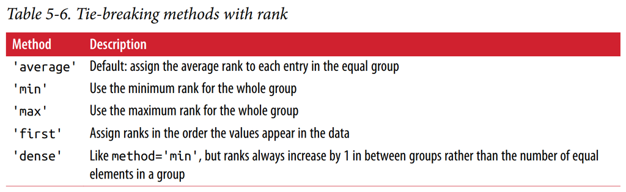

### Axis Indexes with Duplicate Labels

While many pandas functions (like `reindex`) require that the labels be unique, it’s not mandatory. Let’s consider a small Series with duplicate indices:

```python
obj = pd.Series(range(5), index=['a', 'a', 'b', 'b', 'c'])
obj
```

```
a    0
a    1
b    2
b    3
c    4
dtype: int64
```

The index’s `is_unique` property can tell you whether its labels are unique or not:

```python
obj.index.is_unique
```

```
False
```

- Data selection is one of the main things that behaves differently with duplicates.
- Indexing a label with multiple entries returns a Series, while single entries return a scalar value:

```python
obj['a']
```

```
a    0
a    1
dtype: int64
```

The same logic extends to indexing rows in a DataFrame:

```python
df = pd.DataFrame(np.random.randn(4, 3), index=['a', 'a', 'b', 'b'])
df
```

|  | 0 | 1 | 2 |
| --- | --- | --- | --- |
| a | -0.445385 | -1.112716 | 1.132571 |
| a | 0.698273 | -0.595380 | 1.102533 |
| b | 1.810408 | -1.365743 | -0.644842 |
| b | 0.382603 | 0.436527 | -1.961487 |

```python
df.loc['b']
```

|  | 0 | 1 | 2 |
| --- | --- | --- | --- |
| b | 1.810408 | -1.365743 | -0.644842 |
| b | 0.382603 | 0.436527 | -1.961487 |